# Filtered Fit: FCA and the GDSTM

## Filtered ML fit and the GDSTM with FRESA.CAD

Here we make use of the **FRESA.CAD::filteredfit()** function to train ML models with and without GDSTM on the ARCENE data set.

> Isabelle Guyon, Steve R. Gunn, Asa Ben-Hur, Gideon Dror, 2004. Result analysis of the NIPS 2003 feature selection challenge. In: NIPS.
> [$$Web Link$$](http://books.nips.cc/papers/files/nips17/NIPS2004_0194.pdf)
> . *from: https://archive.ics.uci.edu/ml/datasets/Arcene*

> a. Original owners  
> The data were obtained from two sources: The National Cancer Institute (NCI) and the Eastern Virginia Medical School (EVMS). All the data consist of mass-spectra obtained with the SELDI technique. The samples include patients with cancer (ovarian or prostate cancer), and healthy or control patients.  
> b. Donor of database  
> This version of the database was prepared for the NIPS 2003 variable and feature selection benchmark by Isabelle Guyon, 955 Creston Road, Berkeley, CA 94708, USA (isabelle **‘@’** clopinet.com).

This scrip uses FRESA.CAD and mlbench R packages:

```r
knitr::opts_chunk$set(collapse = TRUE, warning = FALSE, message = FALSE,comment = "#>")

library("FRESA.CAD")
library(mlbench)

op <- par(no.readonly = TRUE)
```

Loading the ARCENE data set

```r
trainLabeled <- read.delim("../Data/trainSet.txt")
validLabeled <- read.delim("../Data/arcene_valid.txt")
wholeArceneSet <- rbind(trainLabeled,validLabeled)


wholeArceneSet$Labels <-  1*(wholeArceneSet$Labels > 0)
wholeArceneSet[,1:ncol(trainLabeled)] <- sapply(wholeArceneSet,as.double)

table(wholeArceneSet$Labels)
```

```
  0   1
112  88
```

Setting some variables for downstream analysis

```r
studyName = "Arcene"
datasetframe <- wholeArceneSet
Outcome <- "Labels"

trainFraction = 0.5
```

Setting the Training and Testing sets

```r
tb <- table(datasetframe[,Outcome])
classNames <- unique(datasetframe[,Outcome])

allrowClass <- datasetframe[,Outcome]
names(allrowClass) <- rownames(datasetframe)

trainsize <- trainFraction*min(tb);
trainSamples <- NULL;
for (theClass in classNames)
{
  classSample <- allrowClass[allrowClass == theClass]
  trainSamples <- c(trainSamples,names(classSample[sample(length(classSample),trainsize)]))
}


datasetframe_train <- datasetframe[trainSamples,]
testSamples <- !(rownames(datasetframe) %in% trainSamples)
datasetframe_test <- datasetframe[testSamples,]

outcomes <- datasetframe_train[,Outcome]

pander::pander(table(datasetframe[,Outcome]),caption="All")
```

All

| 0 | 1 |
| --- | --- |
| 112 | 88 |

```r
pander::pander(table(datasetframe_train[,Outcome]),caption="Training")
```

Training

| 0 | 1 |
| --- | --- |
| 44 | 44 |

```r
pander::pander(table(datasetframe_test[,Outcome]),caption="Testing")
```

Testing

| 0 | 1 |
| --- | --- |
| 68 | 44 |

## Machine Learning with the filterfit() function

Train a simple Logistic model with LASSO

```r
system.time(mLASSORaw <- filteredFit(paste(Outcome,"~."),
                   datasetframe_train,
                   fitmethod=LASSO_MIN,
                     filtermethod=univariate_Wilcoxon,
                     filtermethod.control=list(pvalue=0.05,limit= -1),
                    family = "binomial"
                   ))
```

user system elapsed 10.69 0.04 10.75

Now we run **filterfit**() with decorrelation

```r
system.time(mLASSODecor <- filteredFit(paste(Outcome,"~."),
                   datasetframe_train,
                    fitmethod=LASSO_MIN,
                     filtermethod=univariate_Wilcoxon,
                     filtermethod.control=list(pvalue=0.05,limit= -1),
                     DECOR = TRUE,
                     family = "binomial"
                   ))
```

user system elapsed 714.17 17.62 409.38

### Predicting the Testinig Set

```r
par(mfrow=c(1,2))


psRaw <- predictionStats_binary(cbind(datasetframe_test$Labels,
                                      predict(mLASSORaw,datasetframe_test)),
                                "LASSO Raw",cex=0.75)
```

LASSO Raw

```r
pander::pander(psRaw$aucs)
```

| est | lower | upper |
| --- | --- | --- |
| 0.7152 | 0.6209 | 0.8096 |

```r
psDecor <- predictionStats_binary(cbind(datasetframe_test$Labels,
                                        predict(mLASSODecor,datasetframe_test)),
                                "LASSO after GDSTM",cex=0.75)
```

LASSO after GDSTM

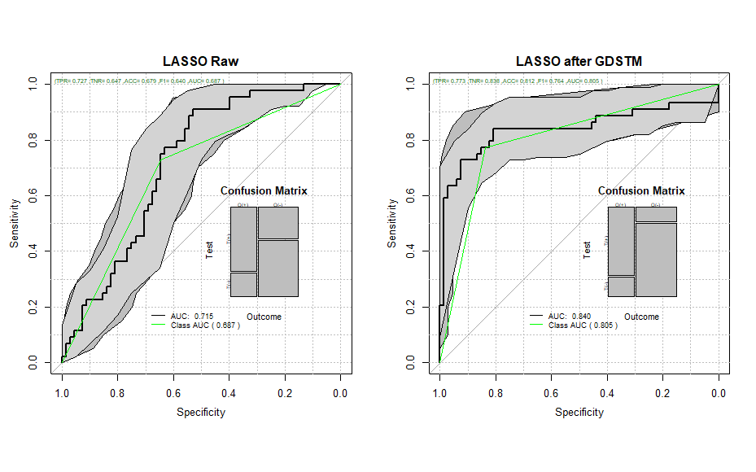

```r
pander::pander(psDecor$aucs)
```

| est | lower | upper |
| --- | --- | --- |
| 0.8399 | 0.7482 | 0.9316 |